# Markdown Workshop

Divya and Elisa

23 5 2020

# Let’s make a Markdown html together

You now have the rendered html text, let’s discuss what went into making this text, i.e. what all should your text be able to do to render this document?

At the last Tidy Tuesday event, there was a discussion to make a kind of template for how we do Tidy Tuesday. In this document, I can explain to you how I went about creating my last Tidy Tuesday plot. I want to use the Tidy Tuesday data on Traumatic Brain Injury (TBI). I worked on this on our Meetup from 19.05.2020, although the data was posted earlier this year.

If you have a similar dataset, you can do so for that script. If not, just use mine :)

Something to help you along the way

- Shortcut to convert an r script to a markdown file CTRL + Shift + k on windows OR Cmd + Shift + k on macOS
- Shortcut to create r code chunks CTRL + ALT + i on windows OR Cmd + Option + I on macOS

## Starting off with R Markdown

You can start a new markdown file by going to file-> new file-> R Markdown. Give it a title and select HTML - you can always change these later. The document that shows up already has some information about Markdown. What does this tell us?

1. KnitR
2. Headers and Text
3. R-chunks
4. Echo function within chunks.

## Pre-processing

First I import my data. There were three datasets to choose from (or use together). I chose the one with age and number of cases of TBI in the year 2014. I do not need to show you the output that says the csv has been included, so here, I can use echo=False, and include=FALSE. What is the difference?

This is variable a fromo params 1 The first thing I would do is simply look at the data. Open the table and look at it, use the str() and summary() functions. The question I ask here is - do I need to change anything to be able to plot my dataset?

```r
str(tbi_age)
```

```
## Classes 'tbl_df', 'tbl' and 'data.frame':    231 obs. of  5 variables:
##  $ age_group       : chr  "0-17" "0-17" "0-17" "0-17" ...
##  $ type            : chr  "Emergency Department Visit" "Emergency Department Visit" "Emergency Department Visit" "Emergency Department Visit" ...
##  $ injury_mechanism: chr  "Motor Vehicle Crashes" "Unintentional Falls" "Unintentionally struck by or against an object" "Other unintentional injury, mechanism unspecified" ...
##  $ number_est      : int  47138 397190 229236 55785 NA 24360 57983 5464 230776 53436 ...
##  $ rate_est        : num  64.1 539.8 311.6 75.8 NA ...
##  - attr(*, "spec")=List of 2
##   ..$ cols   :List of 5
##   .. ..$ age_group       : list()
##   .. .. ..- attr(*, "class")= chr  "collector_character" "collector"
##   .. ..$ type            : list()
##   .. .. ..- attr(*, "class")= chr  "collector_character" "collector"
##   .. ..$ injury_mechanism: list()
##   .. .. ..- attr(*, "class")= chr  "collector_character" "collector"
##   .. ..$ number_est      : list()
##   .. .. ..- attr(*, "class")= chr  "collector_integer" "collector"
##   .. ..$ rate_est        : list()
##   .. .. ..- attr(*, "class")= chr  "collector_double" "collector"
##   ..$ default: list()
##   .. ..- attr(*, "class")= chr  "collector_guess" "collector"
##   ..- attr(*, "class")= chr "col_spec"
```

You can already see the output here looks a bit untidy, so let’s try and plot the summary in a table.

I will run `unique(tbi_age$injury_mechanism)`

The Injury mechanismos are: Motor Vehicle Crashes, Unintentional Falls, Unintentionally struck by or against an object, Other unintentional injury, mechanism unspecified, Intentional self-harm, Assault, Other or no mechanism specified

```r
summary<-summary(tbi_age)

knitr::kable(summary, caption = 'Summary Table of TBI_Age')
```

Summary Table of TBI_Age

|  | age_group | type | injury_mechanism | number_est | rate_est |
| --- | --- | --- | --- | --- | --- |
|  | Length:231 | Length:231 | Length:231 | Min. : 16.0 | Min. : 0.000 |
|  | Class :character | Class :character | Class :character | 1st Qu.: 603.8 | 1st Qu.: 1.375 |
|  | Mode :character | Mode :character | Mode :character | Median : 2581.0 | Median : 5.750 |
|  | NA | NA | NA | Mean : 29960.6 | Mean : 50.973 |
|  | NA | NA | NA | 3rd Qu.: 17431.5 | 3rd Qu.: 43.850 |
|  | NA | NA | NA | Max. :1213412.0 | Max. :1442.500 |
|  | NA | NA | NA | NA’s :11 | NA’s :11 |

Because you can see my output, you can also see fr yourself that age is not a factor, and is honestly arranged a bit weirdly. If I want to plot age, I need age to be a factor. I would also like it to be ordered in an ascending order that makes sense while looking at it. So I make these two changes.

```r
tbi_age$age_group<-as.factor(tbi_age$age_group)
tbi_age$age_group <- ordered(tbi_age$age_group, levels = c("0-4", "5-14", "15-24", "25-34", "35-44", "45-54", "55-64", "65-74", "75+"))

tbi_age<-na.omit(tbi_age)
```

## Making the Plot

I want to make a simple Bar graph, but for this Tidy Tuesday, I wanted to learn how to add a background image to my ggplot. For these, I need the following ggplot2, but also ggimage, magick and cowplot. I will also be using the Game of Thrones colour palette, so I’ll call this package as well.

I do not need to show you how my packages run, so here, I can use *echo=False*, and *include=FALSE*.

Now the plot itself took a bit of trial and error which I will not go into, but I will explain what I am doing here.

```r
bar_plot<-ggplot(tbi_age, aes(x=age_group, y=number_est, fill=type)) +
  geom_bar(position="dodge",stat="identity", width=1) +
  scale_fill_got_d(option = "Lannister", direction = - 1)+
  labs(title="Tidy Tuesdays",
       subtitle="Number of cases of Traumatic Brain Injury per Age-Group",
       caption="R-Ladies Freiburg, 19.05.2020",
       y="Number of Cases of TBI",
       x="Age Group")+
  theme(
    panel.grid.major = element_blank(),
    panel.grid.minor = element_blank(),
    panel.background = element_rect(fill = "transparent",colour = NA),
    plot.background = element_rect(fill = "transparent",colour = NA),
    axis.text.x=element_text(angle=50, size=14, colour= "black", vjust=0.5),
    axis.text.y=element_text(size=14, colour= "black"),
    plot.title = element_text(size=20, face="bold", margin = margin(10, 0, 10, 0))
  )


img = image_read('presentation-figure/photo-1510698454686-1e2552e058e0.jpg')
#image_info(img)
```

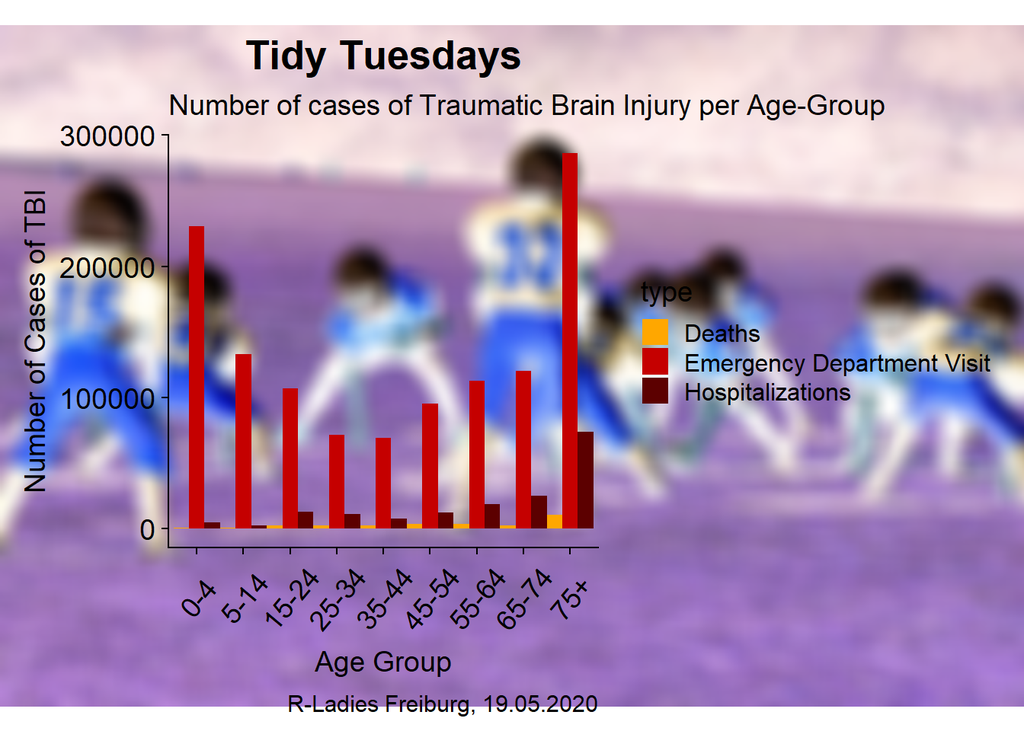

```r
img2<-image_negate(img)
img3<-image_blur(img2, 6, 5)

options(scipen=999)

ggdraw() +
  draw_image(img3) +
  draw_plot(bar_plot)
```

So this was an easy ways for you to follow what I did and replicate my code.

# References

## Reference Oslo

[Reports to impress your boss - R-Ladies Oslo](https://www.youtube.com/watch?v=Xn5AmUf7gDQ)

## Reference Book

[R-Markdown the definative guide](https://bookdown.org/yihui/rmarkdown/)